# Data visualization with ggplot2

Visualizing data in R with the ggplot2 package

### Learning Objectives

> - Visualize data using base R
> - Visualize the same plot using R ggplot2 package
> - Build step-by-step complex plots with the ggplot2 package

For more details and additional tutorials on using ggplot2, see the [official documentation](http://docs.ggplot2.org/current/).

Load required packages.

```r
library(dplyr)
```

```r
library(ggplot2)
```

Load or reload NHTS data.

```r
nhts_per <- readr::read_csv("data/nhts_per.csv",
                            na = c("", "NA", -1, -8, -5, -4)) %>%
  select(HOUSEID, HHSIZE, HHVEHCNT, TIMETOWK, YEARMILE, USEPUBTR)
```

## Base plotting

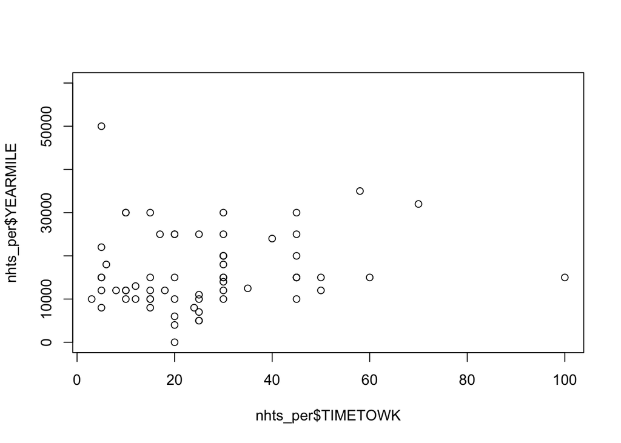

```r
plot(x = nhts_per$TIMETOWK, y = nhts_per$YEARMILE)
```

And for categorical variables let’s plot a bar chart, using basic R plotting capabilities.

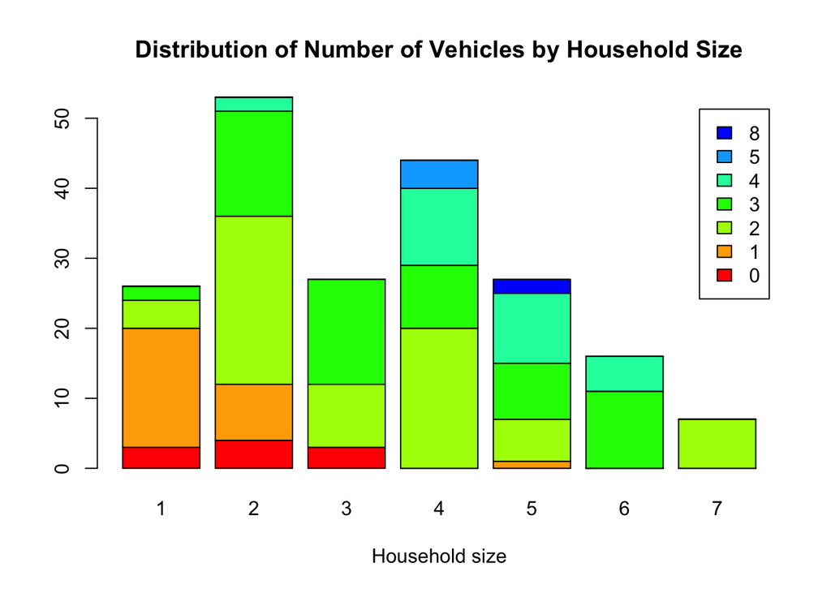

```r
counts <- table(nhts_per$HHVEHCNT, nhts_per$HHSIZE)
barplot(counts,
        col = rainbow(9),
        legend = rownames(counts), xlab = "Household size",
        main = "Distribution of Number of Vehicles by Household Size")
```

## Plotting with ggplot2

We will make the same two plots using the `ggplot2` package. `ggplot2` is a plotting package that makes it simple to create complex plots from data in a dataframe. It uses default settings, which help create publication quality plots with a minimal amount of settings and tweaking.

`ggplot2` graphics are built step by step by adding new elements.

To build a ggplot we need to:

1. Bind the plot to a specific data frame using the `data` argument.

```r
ggplot(data = nhts_per)
```

2. Define aesthetics (`aes`), which maps variables in the data to axes on the plot or to plotting size, shape color, etc.

```r
ggplot(data = nhts_per, aes(x = TIMETOWK, y = YEARMILE))
```

3. Add `geoms`, which define the graphical representation of the data in the plot (points, lines, bars). To add a geom to the plot use `+` operator. Anything you put in the `ggplot()` function can be seen by any geom layers that you add.

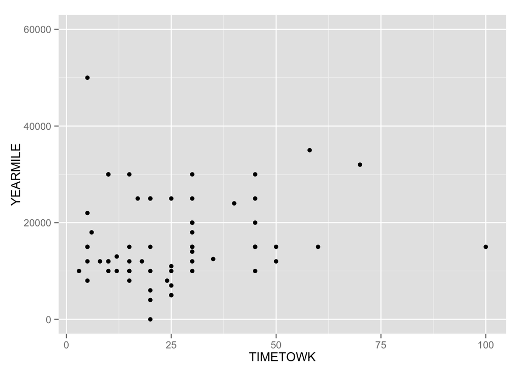

```r
ggplot(data = nhts_per, aes(x = TIMETOWK, y = YEARMILE)) +
  geom_point()
```

4. Add better labeling.

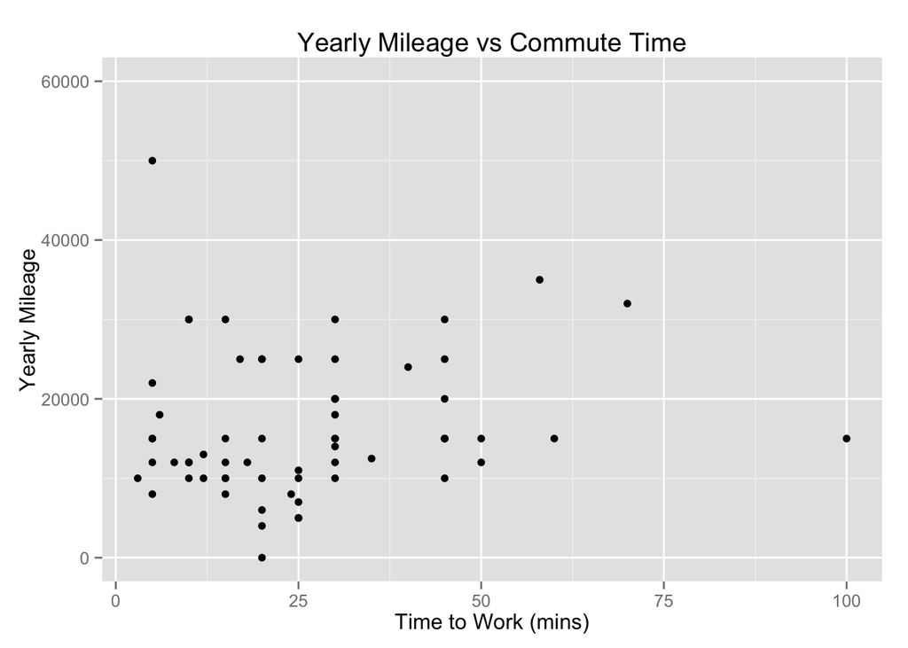

```r
ggplot(data = nhts_per, aes(x = TIMETOWK, y = YEARMILE)) +
  geom_point() +
  labs(title = 'Yearly Mileage vs Commute Time',
       x = 'Time to Work (mins)',
       y = 'Yearly Mileage')
```

5. Add a theme.

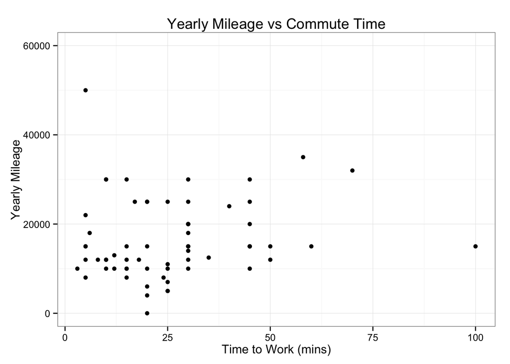

```r
ggplot(data = nhts_per, aes(x = TIMETOWK, y = YEARMILE)) +
  geom_point() +
  labs(title = 'Yearly Mileage vs Commute Time',
       x = 'Time to Work (mins)',
       y = 'Yearly Mileage') +
  theme_bw()
```

Sometimes adding color and transparency adds meaning to the plot. In this case, since we limited the number of rows of the NHTS data to 200, there is not much overlap. But with a lot of points, alpha can be very helpful.

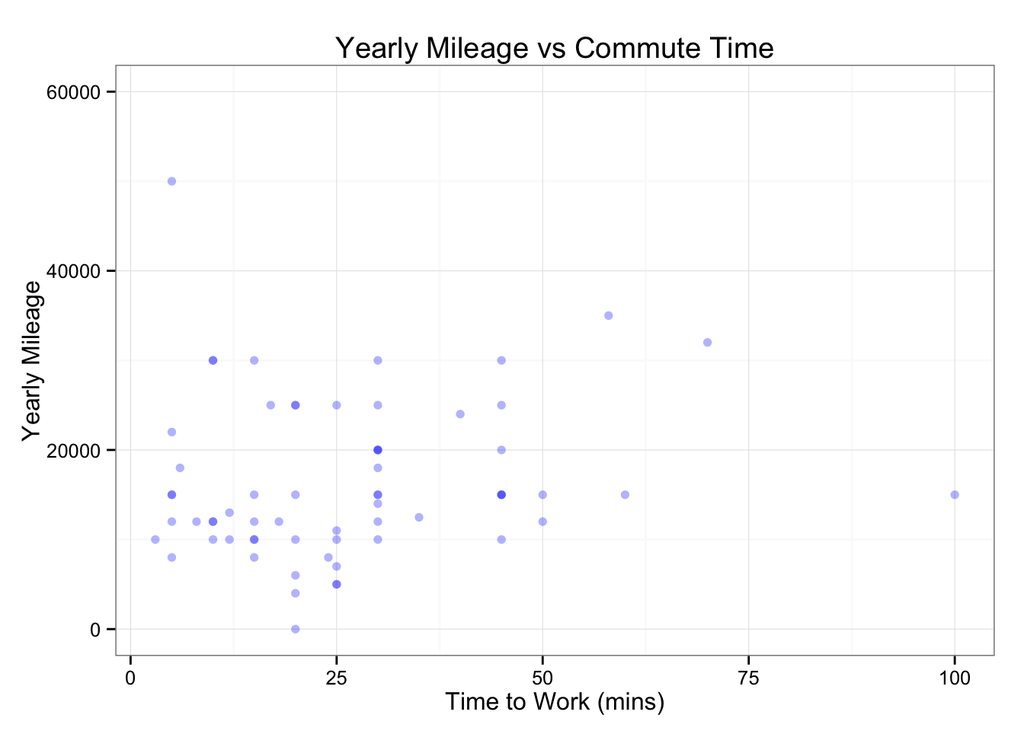

```r
ggplot(data = nhts_per, aes(x = TIMETOWK, y = YEARMILE)) +
  geom_point(alpha = 0.3, color = "blue") +
  labs(title = 'Yearly Mileage vs Commute Time',
       x = 'Time to Work (mins)',
       y = 'Yearly Mileage') +
  theme_bw()
```

Let’s try the barplot. Notice we need to convert the categorical data to factors. Ggplot2 treats factors and numbers differently when plotting. If you get an error with ggplot2, it is good practice to check to see that your categorical variables are factors and that are numeric variables are not.

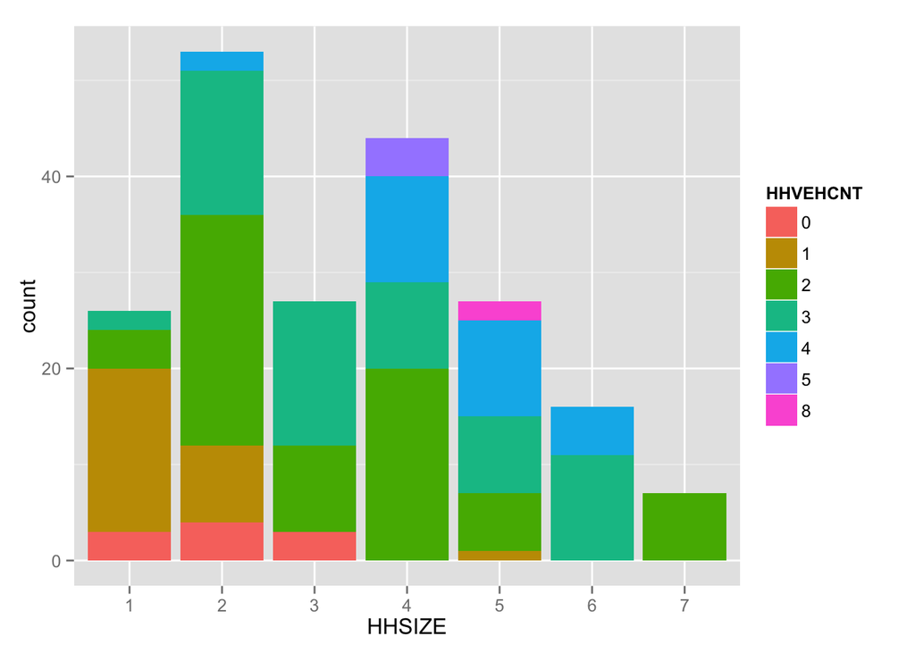

```r
nhts_per <- nhts_per %>%
  mutate(
    HHSIZE = as.factor(HHSIZE),
    HHVEHCNT = as.factor(HHVEHCNT),
    USEPUBTR = factor(USEPUBTR, levels = c("01", "02"), labels = c("Yes", "No"))
  )
ggplot(data = nhts_per, aes(x = HHSIZE, fill = HHVEHCNT)) +
  geom_bar()
```

## Faceting

`ggplot2` has a special technique called *faceting* that allows to split one plot into multiple plots based on some factor.

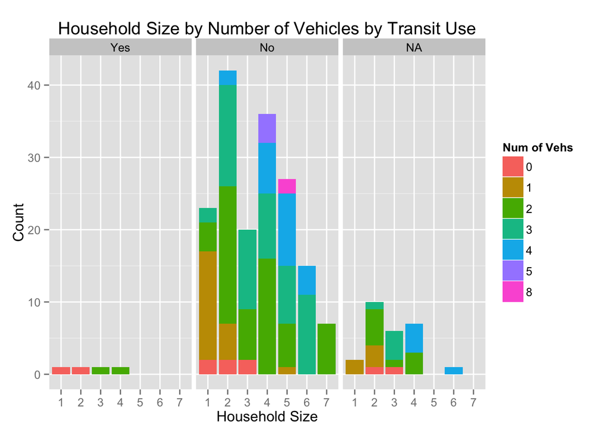

```r
ggplot(data = nhts_per, aes(x = HHSIZE, fill = HHVEHCNT)) +
  geom_bar() +
  facet_grid(. ~ USEPUBTR) +
  labs(title = 'Household Size by Number of Vehicles by Transit Use',
       x = 'Household Size',
       y = 'Count') +
  guides(fill = guide_legend(title = "Num of Vehs"))
```

Here are some ideas:

- See if you can change thickness of the lines.
- Can you find a way to change the name of the legend? What about its labels?
- Use different color palette to improve the look (http://www.cookbook-r.com/Graphs/Colors_(ggplot2)/)

Enjoy plotting with ggplot2!